# Introduction to R Functions

February 26, 2021

## Overview

- Hands on examples
- Repo: https://github.com/skirmer/functions_r
- Support Team for questions

## What is a Function Anyway?

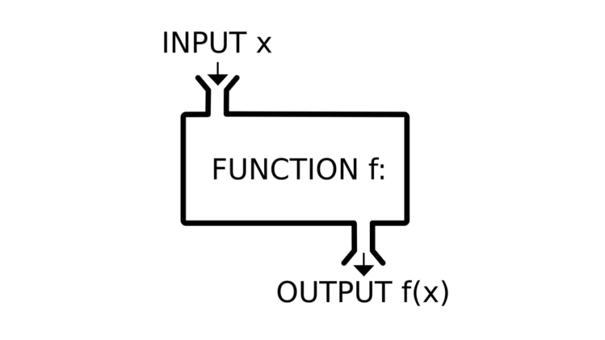

## Why Functions?

- Avoid repetition
- Share code with others
- Eventually build packages

## Basic Structure

```r
myFunction <- function(){
  ...
  return()
}

myFunction()
```

## Basic Structure

```r
myFunction <- function(ARGUMENTS){
  ...
  return(OUTPUT)
}

myFunction(ARGUMENTS)
```

## Basic Structure

```r
myFunction <- function(a, b){
  c <- a*b
  return(c)
}

myFunction(a = 2,b = 4)
```

## Practice Break

Open possible_dog_part1.R and follow the instructions.

## Types

- Logical or Boolean (TRUE, FALSE, 0, 1)
- Integer (3, 7, 108)
- Float or Numeric (1.6645, 3.14159, 987.99)
- String or Character (“Hello”, “a”)

## Arguments, or What Goes In

- Order and naming
- Defaults

```r
myFunction <- function(a=1, b=1){

  ...

myFunction(a = 2,b = 4)
```

## Practice Break

Open possible_dog_part2.R and follow the instructions.

## Returns, or What Comes Out

```r
myFunction <- function(a, b){
...
  return(c)
}
```

## Practice Break

Open possible_dog_part3.R and follow the instructions.

## Guardrails: Documentation

```r
#' myFunction
#'
#' @param a Type. Description of what it represents.
#' @param b Type. Description of what it represents.
#'
#' @return Type. Description of what it represents.
#'
#' @examples
#' \dontrun{myFunction(a = 5, b = 3)}
```

## Practice Break

Open possible_dog_part4.R and follow the instructions.

## Guardrails: Type Check

```r
myFunction <- function(a, b){
  if(!is.numeric(a)) stop("a must be a number")
  c <- a*b
  return(c)
}

myFunction(a = 2,b = 4)
#myFunction(a = TRUE, b = 4)
```

## Guardrails: Tests

```r
library(testthat)
myFunction <- function(a, b){
  if(!is.numeric(a)) stop("a must be a number")
  c <- a*b
  return(c)
}

test_that("Function returns correct value",
          {
            product = myFunction(a = 2,b = 4)
            expect_equal(product, 8)

          })
```

## Guardrails: Tests

```r
library(testthat)

test_that("Function returns expected error",
          {
            expect_error(myFunction(a = TRUE, b = 4))
          })
```

## Environment

The function knows what exists inside itself, and what exists in the “global” environment. Outside the function only knows what exists in the “global”. Here, a, b, and c do not exist in the world outside our function.

```r
print(environment())
print(objects())
myFunction <- function(a, b){
  c <- a*b
  print(environment())
  print(objects())
  return(c)
}

myFunction(a = 2,b = 4)
```

## Global Environment

```r
print(environment())
```

```
## <environment: R_GlobalEnv>
```

```r
print(objects())
```

```
## [1] "myFunction"
```

## Function Environment

```r
myFunction <- function(a, b){
  c <- a*b
  print(environment())
  print(objects())
  return(c)
}

myFunction(a = 2,b = 4)
```

```
## <environment: 0x7fc2c73869c8>
## [1] "a" "b" "c"
```

```
## [1] 8
```

## Exploring

```r
dplyr::top_n
```

```
## function (x, n, wt)
## {
##     lifecycle::signal_superseded("1.0.0", "top_n()", "slice_max()")
##     wt <- enquo(wt)
##     if (quo_is_missing(wt)) {
##         vars <- tbl_vars(x)
##         wt_name <- vars[length(vars)]
##         inform(glue("Selecting by ", wt_name))
##         wt <- sym(wt_name)
##     }
##     filter(x, top_n_rank({
##         {
##             n
##         }
##     }, !!wt))
## }
## <bytecode: 0x7fc2a01ca7a0>
## <environment: namespace:dplyr>
```

## Combining Functions

- A function can be an argument to another function
- This way you can chain together elements powerfully

```r
a <- sum(1, 5, 3)
b <- max(a, 4)
b
```

```
## [1] 9
```

```r
c <- max(sum(1, 5, 3), 4)
c
```

```
## [1] 9
```

## Conclusion

- Functions are a way of packaging small sections of code to reuse later
- Functions accept input and return output, and contain code
- Functions can have documentation and internal tests

## Further Reading

- http://adv-r.had.co.nz/Functions.html
- https://r4ds.had.co.nz/functions.html
- https://nicercode.github.io/guides/functions/
- https://cran.r-project.org/doc/manuals/r-release/R-intro.html#Writing-your-own-functions